# Recruiting Quality Analysis

## Predicted Individuals Probability of Being Drafted

We will be utilizing a classification model with 5 cross-folds (or resampling of data for training & testing the model) to build a prediction model. As we previewed the variables we intend to add to our model consist of the following: HS Rating (on a 0 to 1 scale), conference the individual played in, mean points per attempt (mean_ppa), success rate, yards per carry (ypc), career rush yards, successes, success yards, career Touchdowns, and years of college playing experience. Our first model will be to build an XGBoost Tree model that uses gradient boosted decision tree to rank and order important variables. XGBoost models work well in cases where there are a mixture of categorical (such as conference) and numeric field. The concept of gradient booting is an ensemble of decision trees designed to enhance the learning of the decision trees. The goal is to spend much more time on weak learners to optimize or boot its learning capability and reduce information loss. It does so in batch or ensemble learning.

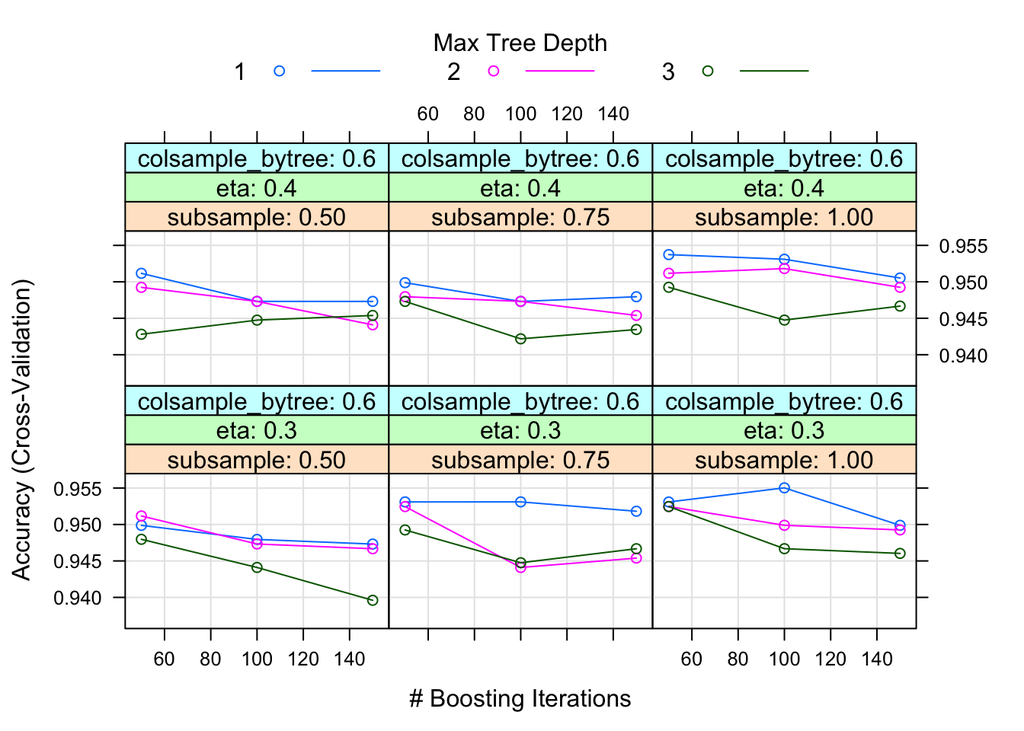

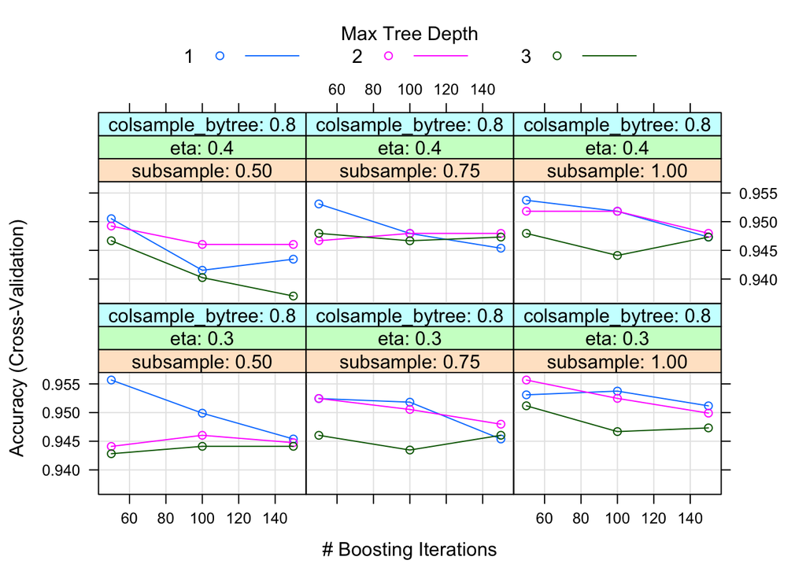

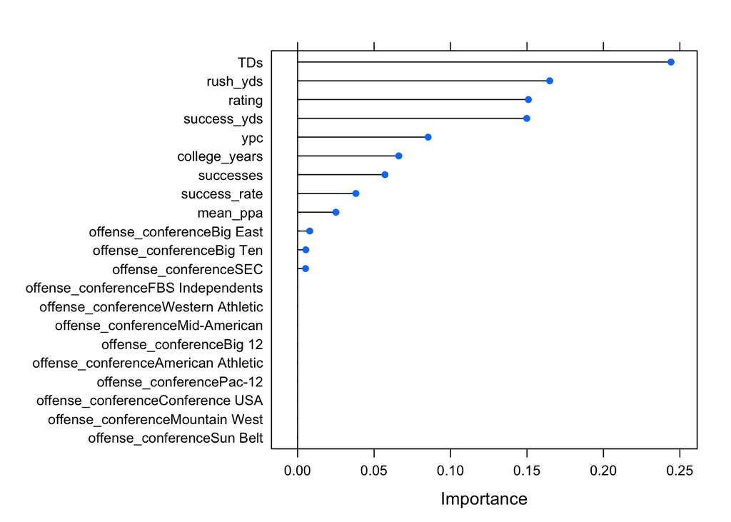

```
##
## Call:
## NULL
##
## Deviance Residuals:
##     Min       1Q   Median       3Q      Max
## -2.7405  -0.2519  -0.1659  -0.0766   3.2391
##
## Coefficients:
##                                         Estimate Std. Error z value Pr(>|z|)
## (Intercept)                           -8.909e+00  2.352e+00  -3.787 0.000152
## rating                                 6.605e+00  2.455e+00   2.691 0.007132
## `offense_conferenceAmerican Athletic` -1.410e+01  7.084e+02  -0.020 0.984119
## `offense_conferenceBig 12`            -4.266e-01  5.331e-01  -0.800 0.423557
## `offense_conferenceBig East`           2.423e-02  6.435e-01   0.038 0.969963
## `offense_conferenceBig Ten`           -1.026e-01  5.266e-01  -0.195 0.845495
## `offense_conferenceConference USA`    -1.811e+00  8.633e-01  -2.097 0.035971
## `offense_conferenceFBS Independents`  -4.228e-01  1.180e+00  -0.358 0.720073
## `offense_conferenceMid-American`      -1.778e+00  9.596e-01  -1.853 0.063907
## `offense_conferenceMountain West`     -1.345e+00  9.287e-01  -1.448 0.147608
## `offense_conferencePac-12`             2.522e-01  4.802e-01   0.525 0.599492
## offense_conferenceSEC                  4.373e-01  4.682e-01   0.934 0.350281
## `offense_conferenceSun Belt`          -2.505e+00  1.274e+00  -1.966 0.049349
## `offense_conferenceWestern Athletic`   4.081e-01  8.189e-01   0.498 0.618249
## mean_ppa                              -5.140e-01  6.359e-01  -0.808 0.418887
## success_rate                          -6.660e-02  1.367e+00  -0.049 0.961158
## ypc                                    2.286e-02  6.818e-02   0.335 0.737419
## rush_yds                              -1.568e-04  2.248e-03  -0.070 0.944377
## successes                             -8.822e-03  1.051e-02  -0.839 0.401262
## success_yds                            2.284e-03  2.205e-03   1.036 0.300210
## TDs                                    8.475e-02  3.144e-02   2.696 0.007016
## college_years                         -5.171e-01  1.594e-01  -3.244 0.001180
##
## (Intercept)                           ***
## rating                                **
## `offense_conferenceAmerican Athletic`
## `offense_conferenceBig 12`
## `offense_conferenceBig East`
## `offense_conferenceBig Ten`
## `offense_conferenceConference USA`    *
```

[output cut: 10 more lines]

```
## rush_yds
## successes
## success_yds
## TDs                                   **
## college_years                         **
## ---
## Signif. codes:  0 '***' 0.001 '**' 0.01 '*' 0.05 '.' 0.1 ' ' 1
##
## (Dispersion parameter for binomial family taken to be 1)
##
##     Null deviance: 731.62  on 1555  degrees of freedom
## Residual deviance: 420.64  on 1534  degrees of freedom
## AIC: 464.64
##
## Number of Fisher Scoring iterations: 16
```

The last model will take the same GLM approach but with a lighter and insignificant amount of variables. For this lighter model, we solely included HS rating, success rate, career rush yards, total career successes, career success yards, career TDs, and college years.

```
##
## Call:
## NULL
##
## Deviance Residuals:
##     Min       1Q   Median       3Q      Max
## -2.9115  -0.2483  -0.1673  -0.1138   3.4379
##
## Coefficients:
##                 Estimate Std. Error z value Pr(>|z|)
## (Intercept)   -1.278e+01  1.856e+00  -6.887 5.71e-12 ***
## rating         1.131e+01  1.986e+00   5.698 1.21e-08 ***
## success_rate  -6.184e-01  9.981e-01  -0.620  0.53555
## rush_yds       4.473e-04  2.118e-03   0.211  0.83277
## successes     -1.476e-02  9.647e-03  -1.530  0.12607
## success_yds    2.129e-03  2.099e-03   1.014  0.31042
## TDs            7.724e-02  3.014e-02   2.563  0.01038 *
## college_years -5.046e-01  1.552e-01  -3.252  0.00115 **
## ---
## Signif. codes:  0 '***' 0.001 '**' 0.01 '*' 0.05 '.' 0.1 ' ' 1
##
## (Dispersion parameter for binomial family taken to be 1)
##
##     Null deviance: 731.62  on 1555  degrees of freedom
## Residual deviance: 442.44  on 1548  degrees of freedom
## AIC: 458.44
##
## Number of Fisher Scoring iterations: 7
```

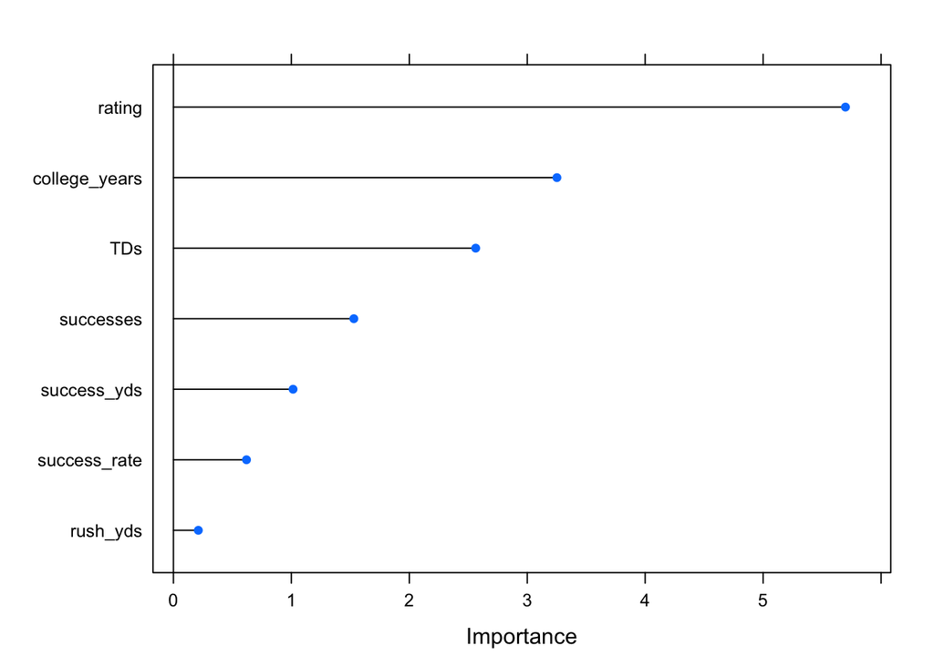

```
##
##  Hosmer and Lemeshow goodness of fit (GOF) test
##
## data:  dfc.train$rush_drafted, fitted(pts_glm1)
## X-squared = 1556, df = 8, p-value < 2.2e-16
```

```
##
##      FALSE       TRUE
## 0.03675345 0.96324655
```

```
##
##      FALSE       TRUE
## 0.04562982 0.95437018
```

Using this model, we can predict based off RBs career stats, the probability of that runningback getting drafted. The table below shows the Top 20 in probability of getting drafted as a running back in the NFL.